# Introduction

This notebook investigates a dataset of IMDB reviews with the goal of building tools to better understand the text and its words in an accessible way, as well as the sentiment they convey.  
The process begins with an initial exploration of the data, followed by cleaning and preprocessing steps such as lemmatization and n-gram extraction.

The analysis is organized into two complementary parts:

1. **Knowledge extraction**
   - *Word2Vec* is applied to learn semantic relationships between words and concepts in the dataset.
   - *Latent Dirichlet Allocation (LDA)* is used to discover overarching themes across reviews.
2. **Sentiment prediction**
   - A classical baseline model (*Logistic Regression*) is trained on the processed text.
   - A transformer-based model (*DistilBERT*) is fine-tuned for classification.
   - The performance of both approaches is compared, emphasizing their differences in accuracy, interpretability, and computational cost.

Through these steps, the notebook combines exploratory linguistic analysis with predictive modeling, offering insights into how movie reviews can be examined at both the lexical and semantic level, and how sentiment can be effectively captured using different approaches.

# 1. Preprocess Data

## 1.1 Data load and overview

Thanks to *GeeksforGeeks* for sharing this dataset:  
https://www.geeksforgeeks.org/dataset-for-sentiment-analysis/#1-imdb-reviews-dataset

```python
import pandas as pd
df = pd.read_csv('IMDB-Dataset.csv')
df.head()
```

|  | review | sentiment |
| --- | --- | --- |
| 0 | One of the other reviewers has mentioned that ... | positive |
| 1 | A wonderful little production. <br /><br />The... | positive |
| 2 | I thought this was a wonderful way to spend ti... | positive |
| 3 | Basically there's a family where a little boy ... | negative |
| 4 | Petter Mattei's "Love in the Time of Money" is... | positive |

```python
df.describe()
```

|  | review | sentiment |
| --- | --- | --- |
| count | 50000 | 50000 |
| unique | 49582 | 2 |
| top | Loved today's show!!! It was a variety and not... | positive |
| freq | 5 | 25000 |

Let's see how many words the reviews usually have.

```
Min words:  4
Max words:  2470
```

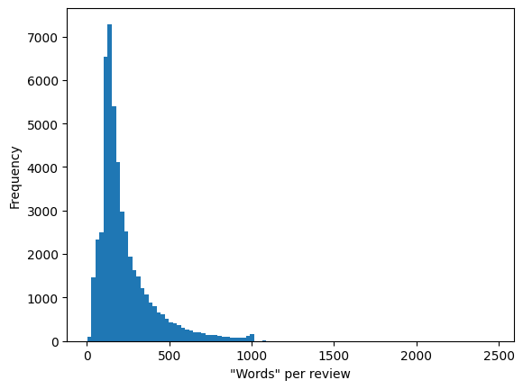

```python
print("Min words: ", df['review'].str.split().apply(len).min())
print("Max words: ", df['review'].str.split().apply(len).max())

df['review'].str.split().apply(len).plot(kind='hist', bins=100).set_xlabel('"Words" per review')
```

The otuput shows that reviews vary in length from 4 to 2,470 words. However, most reviews tend to fall between 20 and 500 words, with reviews exceeding 1,000 words being extremely rare.

Additionally, we might question the value of keeping reviews with fewer than 10 words. Let's examine what these extremely short reviews look like.

```python
df[df['review'].str.split().apply(len) <= 10]
```

|  | review | sentiment |
| --- | --- | --- |
| 11926 | I wouldn't rent this one even on dollar rental... | negative |
| 13109 | More suspenseful, more subtle, much, much more... | negative |
| 18400 | Brilliant and moving performances by Tom Court... | positive |
| 19874 | This movie is terrible but it has some good ef... | negative |
| 27521 | Read the book, forget the movie! | negative |
| 28920 | Primary plot!Primary direction!Poor interpreta... | negative |
| 31072 | What a script, what a story, what a mess! | negative |
| 40817 | I hope this group of film-makers never re-unites. | negative |

Since these are meaningful reviews, there is no reason to delete them. However, there is a potential error, such as words without spaces, like: "*direction!Poor interpreta...*". Write down this task!

Another common issue in this kind of data is the presence of misspelled words. To examine this, it is possible to view words that appear less than 3 times in the dataset:

```python
from collections import Counter

words = Counter()
df['review'].str.split().apply(words.update)
words = pd.Series(words)
print("Number of words (repeated less than 3 times): ", len(words[words < 3]))
words[words < 3].head(10)
# Export to get an idea of why these words are uncommon
#pd.DataFrame(words[words < 3]).to_csv('words.csv')
```

```
Number of words (repeated less than 3 times):  322327
```

|  | 0 |
| --- | --- |
| GO. | 2 |
| Penitentary. | 1 |
| inwards, | 2 |
| many..Aryans, | 1 |
| gangstas, | 1 |
| more....so | 1 |
| scuffles, | 1 |
| romance...OZ | 1 |
| (crooked | 1 |
| nickel, | 2 |

**dtype:** int64

After exporting and briefly reviewing the least frequent words in VS, only a few misspellings were identified. While some typos do exist (e.g., "*schoiol*"), the vast majority of uncommon words are caused by punctuation being attached to words.

There are also a few domain-specific expressions like "*re-watchable*" or proper nouns such as "*Kahlua*" or "*Heffernan*". Additionally, a wide number of occurrences are due to the words being in uppercase.

In addition, it is important to identify those elements of digital communication that differ from natural language: e-mails, links, HTML tags, etc.

```python
import re

html_tags = set()
for review in df['review']:
    # find text inside HTML-like tags, i.e., "<...>"
    matches = re.findall(r"<[^>]+>", review)
    html_tags.update(matches)

print("--------HTML uniques--------")
print(html_tags, "\n")

hash_words = set()
for review in df['review']:
   # match "#" followed by one or more characters
    matches = re.findall(r"#\w+", review)
    hash_words.update(matches)

print("--------# uniques--------")
print(hash_words, "\n")

at_words = set()
for review in df['review']:
  # Same regex but to find mentions or emails, i.e., "@Kelly knows this"
    matches = re.findall(r"@\w+", review)
    at_words.update(matches)

print("--------@ uniques--------")
print(at_words, "\n")

word_com = set()
for review in df['review']:
  # words ending in ".com"
    matches = re.findall(r"\w+\.com", review)
    word_com.update(matches)

print("--------.com uniques--------")
print(word_com)
```

```
--------HTML uniques--------
{'<<<<< ......... ......... ........................ ................ ..................... .................. .............. ............ ................<br />', '<<<sigh>', '< who was to be a victim, but woman-power trumps evil scientist every time.<br />', '< and make notes for my partial "revie…

--------# uniques--------
{'#91', '#one', '#k', '#Major', '#100', '#o', '#3', '#ck', '#8', '#yawws', '#4', '#216', '#183', '#t', '#16', '#2', '#7', '#269', '#comment', '#8230', '#hole', '#17', '#SPOILERS', '#85', '#K', '#10', '#8217', '#232', '#305', '#240', '#15', '#18', '#1', '#s', '#cking', '#mn', '#26', '#61514', '#40', …

--------@ uniques--------
{'@hotmail', '@midohio', '@earthlink', '@rn', '@verizon', '@AOL', '@adelphia', '@_', '@K', '@ckin', '@itv', '@aol', '@let', '@g', '@ing', '@ppy', '@talkamerica', '@sidwell', '@googlemail', '@ERS', '@Yahoo', '@nk', '@k', '@pipinternet', '@aim', '@pfest', '@ss', '@ck', '@bbe', '@hot', '@rt', '@the', '…

--------.com uniques--------
{'ifeng.com', 'www.com', 'peterkurth.com', 'lovetrapmovie.com', 'play.com', 'Tv.com', 'PetitionOnline.com', 'threestooges.com', 'poffysmoviemania.com', 'thenewamerican.com', 'filmcritic.com', 'Amazon.com', 'FilmDailies.com', 'jumpedtheshark.com', 'mybluray.com', 'mail.com', 'amargosaoperahouse.com',…
```

Thus, it is concluded that:

- There are various HTML tags, but also other uses of "<>".
- There are many uses of "@", however, a very unscientific `ctrl + f` revealed only 181 instances, and most of the time it's used for insults (i.e.:*$$$#@%@!* or *F@ck*). Therefore, it's preferable to remove the entire row due to its low relevance.
- There are many links that should be removed.

## 1.2 Data cleaning

At this point, the cleanup tasks that have arisen during the exploration and some complementary tasks are carried out.

First, a supplementary column is created to review the transformations.

```python
df['text'] = df['review']
```

Remove: duplicates and long reviews (mentioned memory issues).

```python
df = df.drop_duplicates(subset='review')
df = df[df['review'].str.split().apply(len) <= 250]
```

Remove: "@".

```python
df = df[~df['review'].str.contains(r'@', regex=True)]
```

Remove: links.

```python
# Words ending in "example.com + optional final dot" (where dot must be preserved)
# Complex link: example.com/.../... | Simple link example.com
df['text'] = df['text'].str.replace(r'\S*\.com/\S*\.', '.', regex=True) # Complex + "."
df['text'] = df['text'].str.replace(r'\S*\.com/\S*', ' ', regex=True) # Complex
df['text'] = df['text'].str.replace(r'\S*\.com\.', '.', regex=True) # Simple + "."
df['text'] = df['text'].str.replace(r'\S*\.com\b', ' ', regex=True) # Simple
pd.set_option('display.max_colwidth', 700)
df[df['review'].str.contains(r'http://www.myspace.com/62229249.', regex=True)]
```

|  | review | sentiment | text |
| --- | --- | --- | --- |
| 31431 | The mere fact that I still think of the movie a decade later is what really speaks volumes about the film. To me this substantiates Grand Canyon as a film that will touch you in one way or another. I … | positive | The mere fact that I still think of the movie a decade later is what really speaks volumes about the film. To me this substantiates Grand Canyon as a film that will touch you in one way or another. I … |

Remove: HTML tags.

```python
# It is understood that <SPOILER> is an imdb-specific tag
html_tags = ["<i>", "</i>", "<p>", "</p>", "<br>", "<br />", "<em>", "</em>", "<SPOILER>", "</SPOILER>"] # For some reason <br />, not </br>
for tag in html_tags:
    df['text'] = df['text'].str.replace(tag, " ", regex=False)
df[df['review'].str.contains(r'\.<br /><br />It is a quirky flick', regex=True)]
```

|  | review | sentiment | text |
| --- | --- | --- | --- |
| 90 | "Down Periscope" has been in our library since it first arrived in VHS. Since then, we have acquired the DVD and a digital from Cinema Now.<br /><br />It is a quirky flick that does not go militarily … | positive | "Down Periscope" has been in our library since it first arrived in VHS. Since then, we have acquired the DVD and a digital from Cinema Now. It is a quirky flick that does not go militarily overboard a… |

Remove: #.

```python
# With possible non-space characters \S* before or after
df['text'] = df['text'].str.replace(r"\S*#\S*", " ", regex=True)
df[df['review'].str.contains(r'"Sorte Nula" is the #1 Box')]
```

|  | review | sentiment | text |
| --- | --- | --- | --- |
| 9941 | "Sorte Nula" is the #1 Box Office Portuguese movie of 2004. This extreme low budget production (estimated USD$150,000) opened during Christmas opposite American Blockbusters like National Treasure, Po… | positive | "Sorte Nula" is the Box Office Portuguese movie of 2004. This extreme low budget production (estimated USD$150,000) opened during Christmas opposite American Blockbusters like National Treasure, Polar… |

For a more accurate analysis, rows containing words with numbers will be removed. This decision is made because these values are often spelling mistakes or absurd values. Examples: *addicted2you*, *tt0117979*.

Although some could be modified, such as "*25yrs*" to "*years*", the large size of the dataset (and memory issues) allows this decision to be made as long as not too much data is removed.

```python
print("ºRows previous to drop ->", df.shape[0], "\n")

words_letters_numbers = set()
for review in df['text']:
  # Regex by @Roberto, source, first response:
  # https://stackoverflow.com/questions/44187078/regex-to-get-words-containing-letters-and-numbers-certain-special-but-not-o
    matches = re.findall(r"([A-Za-z]+[\d@]+[\w@]*|[\d@]+[A-Za-z]+[\w@]*)", review)
    words_letters_numbers.update(matches)
print(words_letters_numbers, "\n")

def is_alpha_numeric(text):
    return bool(re.search(r"([A-Za-z]+[\d@]+[\w@]*|[\d@]+[A-Za-z]+[\w@]*)", text))

df = df[~df['text'].apply(is_alpha_numeric)]
print("ºRows after ->", df.shape[0])
```

```
ºRows previous to drop -> 34791

{'h3ll', 'NUMB3RS', '1930ies', 'Dogma95', 'BruceV3', '14th', '2am', 'H2EFW', '2004s', '1980s', 'JP3', '5seconds', '6yrs', '1860s', 'recommanded1', '2h', '1d', '17yo', '1950ies', '230mph', 'ZB2', 'n64', '30pm', '80ish', '1980ies', '5ive', 'part7', '90s', '10yr', '4out5', '60ies', '58minutes', '100ft'…

ºRows after -> 31687
```

Remove: numbers.

```python
df['text'] = df['text'].str.replace(r"\d+", " ", regex=True)
df[df['review'].str.contains(r'This movie made it into one of my top 10 most awful movies')]
```

|  | review | sentiment | text |
| --- | --- | --- | --- |
| 17 | This movie made it into one of my top 10 most awful movies. Horrible. <br /><br />There wasn't a continuous minute where there wasn't a fight with one monster or another. There was no chance for any c… | negative | This movie made it into one of my top most awful movies. Horrible. There wasn't a continuous minute where there wasn't a fight with one monster or another. There was no chance for any character develo… |

Remove: symbols/punctuation.

```python
punctuation = r";:,¡!\"#$~%&\()*©+-=<>/@[\]ªº^_`{|}~?¿" # Note that (') & (.) are not included
df['text'] = df['text'].replace(f"[{re.escape(punctuation)}]", " ", regex=True)
df[df['review'].str.contains(r'"has got all the polari"')]
```

|  | review | sentiment | text |
| --- | --- | --- | --- |
| 1 | A wonderful little production. <br /><br />The filming technique is very unassuming- very old-time-BBC fashion and gives a comforting, and sometimes discomforting, sense of realism to the entire piece… | positive | A wonderful little production. The filming technique is very unassuming very old time BBC fashion and gives a comforting and sometimes discomforting sense of realism to the entire piece. The actors ar… |

Correction of periods.

```python
# multi-dot patterns with or without spaces
df['text'] = df['text'].replace(r"(?:\.\s*){2,}", ". ", regex=True)
df['text'] = df['text'].replace(r"\s*\.\s*", ". ", regex=True)
df[df['review'].str.contains(r'. . . er, sorry . . .')]
```

|  | review | sentiment | text |
| --- | --- | --- | --- |
| 16989 | OK, so I know better than to watch movies on SciFi . . . er, sorry . . . SyFy. Or shifafa. Or whatever it is now. So sue me. I spent my whole Saturday doing advisory-board brainstorming for a nonprofi… | negative | OK so I know better than to watch movies on SciFi. er sorry. SyFy. Or shifafa. Or whatever it is now. So sue me. I spent my whole Saturday doing advisory board brainstorming for a nonprofit. I can be … |

To lowercase.

```python
df['text'] = df['text'].str.lower()
df.head(1)
```

|  | review | sentiment | text |
| --- | --- | --- | --- |
| 1 | A wonderful little production. <br /><br />The filming technique is very unassuming- very old-time-BBC fashion and gives a comforting, and sometimes discomforting, sense of realism to the entire piece… | positive | a wonderful little production. the filming technique is very unassuming very old time bbc fashion and gives a comforting and sometimes discomforting sense of realism to the entire piece. the actors ar… |

Removal of misspelled words.

Although word correction can be as long and complex a task as desired, here it is considered to remove those with 3 or more repeated letters. This means that words such as “grr” will slip through. However, I consider the quality after all the preprocessing to be sufficiently optimal (*garbage in, garbage out*).

```python
print("Previous to drop:")
print(df[df['text'].str.contains(r'stooooooopiddddd', regex=True)]['review'])
df = df[~df['text'].str.contains(r'([a-z])\1{2,}', regex=True, na=False)]
print("\nAfter drop:")
print(df[df['text'].str.contains(r'stooooooopiddddd', regex=True)]['review'])
```

```
Previous to drop:
45877    BOOOOOOOORRRRRINNGGGGGGGG and STOOOOOOOPIDDDDD. Kept falling asleep. If you want to see Miles O'Keefe loping around in a furry Speedo by all means rent this movie. If not please don't bother... Rife with anachronisms. Was this supposed to be set in the Ice Age, the Iron Age, the Steel Age o…
Name: review, dtype: object
```

```
After drop:
Series([], Name: review, dtype: object)
```

Correction of extra spaces.

```python
df['text'] = df['text'].replace(r'\s{2,}', ' ', regex=True)
df['text'] = df['text'].str.strip()
```

Conversion of contractions.

```python
%%capture
!pip install contractions
```

```python
import contractions

df['text']=df['text'].apply(lambda x:contractions.fix(x))
df[df['review'].str.contains(r"While I've")][:1] # -> while i have
```

|  | review | sentiment | text |
| --- | --- | --- | --- |
| 2 | I thought this was a wonderful way to spend time on a too hot summer weekend, sitting in the air conditioned theater and watching a light-hearted comedy. The plot is simplistic, but the dialogue is wi… | positive | i thought this was a wonderful way to spend time on a too hot summer weekend sitting in the air conditioned theater and watching a light hearted comedy. the plot is simplistic but the dialogue is witt… |

How did the dataset turn out? Is it large enough and well balanced?

```python
df = df.sample(frac=0.4, random_state=1) # reduced to 12k rows due to resource constraints
df.describe()
```

|  | review | sentiment | text |
| --- | --- | --- | --- |
| count | 12396 | 12396 | 12396 |
| unique | 12396 | 2 | 12396 |
| top | this is one of the greatest documentaries i've ever seen along with "Dark Days". I have skated for maybe an hour my entire life, and I still love this movie. Peralta and his excellent editor captured … | positive | this is one of the greatest documentaries i have ever seen along with dark days. i have skated for maybe an hour my entire life and i still love this movie. peralta and his excellent editor captured t… |
| freq | 1 | 6214 | 1 |

```
Dups -> False
Size -> (12396, 3)
```

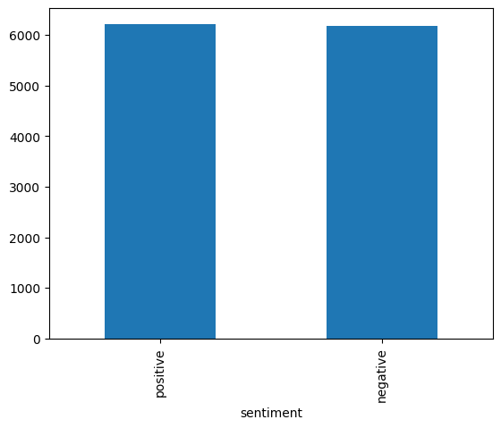

```python
df = df.reset_index(drop=True)
print("Dups ->", df['text'].duplicated().any())
print("Size ->", df.shape) # Enough size
df['sentiment'].value_counts().plot(kind='bar'); # Well balanced
```

# 2. Final data preprocessing

With reasonably clean text, it's time to transform it for use: creating n-grams, tokenization, etc.

First, stopwords are defined. Omitting these values facilitates analysis and significantly increases computing power by eliminating noise or low relevance of these terms.

```python
%%capture
import nltk
from nltk import pos_tag, word_tokenize
from nltk.collocations import *
nltk.download('all')
```

```python
stopwords =  ["would", "'s", "ll"]
stopwords = stopwords + nltk.corpus.stopwords.words('english')
stopwords[:15]
```

```
['would',
 "'s",
 'll',
 'a',
 'about',
 'above',
 'after',
 'again',
 'against',
 'ain',
 'all',
 'am',
 'an',
 'and',
 'any']
```

Secondly, it will be extremely useful to label words according to their grammatical meaning, increasing the possibilities for working with the text.

```python
opinions = " ".join(df['text'])
opinions[:250]
```

```
'a gritty look at new york city and dock workers. this is a classic film realistic brutal at times always believable. it was originally shown live on tv also starring sidney poitier. john cassavetes was a fantastic director and actor. i doubt whoever '
```

```python
tokens = word_tokenize(opinions)
pos_tags = pos_tag(tokens)
print(pos_tags[:10])
```

```
[('a', 'DT'), ('gritty', 'JJ'), ('look', 'NN'), ('at', 'IN'), ('new', 'JJ'), ('york', 'NN'), ('city', 'NN'), ('and', 'CC'), ('dock', 'NN'), ('workers', 'NNS')]
```

Thirdly, n-gram extraction (specifically, bigrams and trigrams) allows relevant sequences of words to be captured, which often convey more meaning than isolated terms. This step helps to identify common expressions, linguistic patterns and contextual relationships that may be useful for further analysis or feature engineering.

In this case, the aim is to see which n-grams exist that could be collocations using a PoS tag filter.

```python
# Load statistical association measures for bigrams and trigrams
bigram_measures = nltk.collocations.BigramAssocMeasures()
trigram_measures = nltk.collocations.TrigramAssocMeasures()

ngrams_num = 300 # top n-grams to extract

# Extract n-grams (2, 3) removing irrelevant characters such as punctuation
bigram_finder = BigramCollocationFinder.from_words(tokens)
bigram_finder.apply_word_filter(lambda w: (re.match(r'\W', w)))
trigram_finder = TrigramCollocationFinder.from_words(tokens)
trigram_finder.apply_word_filter(lambda w: (re.match(r'\W', w)))

# Best PMI - Likehood Ratio
best_bigrams_pmi = bigram_finder.nbest(bigram_measures.pmi, ngrams_num)
best_trigrams_pmi = trigram_finder.nbest(trigram_measures.pmi, ngrams_num)
best_bigrams_lr = bigram_finder.nbest(bigram_measures.likelihood_ratio, ngrams_num)
best_trigrams_lr = trigram_finder.nbest(trigram_measures.likelihood_ratio, ngrams_num)

# Set of Part-of-Speech (PoS) tags
# Adverbs are kept to retain meaningful expressions
avoid_pos = {"DT", "IN", "PRP", "RP", "CC", "CD", "MD"}
# Filter n-grams: remove those starting or ending with stopwords or undesired PoS tags
def filter_ngrams(ngrams):
    filtered = []
    for ng in ngrams:
        first_word, last_word = ng[0], ng[-1]
        first_tag = pos_tag([first_word])[0][1]
        last_tag = pos_tag([last_word])[0][1]

        if first_word not in stopwords and last_word not in stopwords \
           and first_tag not in avoid_pos and last_tag not in avoid_pos:
            filtered.append(ng)
    return filtered

best_bigrams_pmi_filtered = filter_ngrams(best_bigrams_pmi)
best_trigrams_pmi_filtered = filter_ngrams(best_trigrams_pmi)
best_bigrams_lr_filtered = filter_ngrams(best_bigrams_lr)
best_trigrams_lr_filtered = filter_ngrams(best_trigrams_lr)
best_pmi_filtered = best_bigrams_pmi_filtered + best_trigrams_pmi_filtered
best_lr_filtered = best_bigrams_lr_filtered + best_trigrams_lr_filtered
```

```python
best_pmi_filtered = best_bigrams_pmi_filtered + best_trigrams_pmi_filtered
best_lr_filtered = best_bigrams_lr_filtered + best_trigrams_lr_filtered
print("BEST BIGRAMS AND TRIGRAMS PMI:")
print(best_pmi_filtered[:20])
print("\nBEST BIGRAMS AND TRIGRAMS LIKEHOOD RATIO:")
print(best_lr_filtered[:20])
print("\n\nSince the trigrams are not shown, let's see some of them")
print("LR",best_trigrams_lr_filtered[:5])
print("PMI",best_trigrams_pmi_filtered[:5])
```

```
BEST BIGRAMS AND TRIGRAMS PMI:
[('aake', 'sandgren'), ('aatish', 'kapadia'), ('abderrahmane', 'sissako'), ('abortive', 'stillborn'), ('absorbent', 'undergarments'), ('ach', 'jodel'), ('acp', 'anbuselvan'), ('adjoining', 'homesteads'), ('aeneid', 'eneide'), ('afrika', 'korps'), ('agnus', 'schrim'), ('ahmed', 'sellam'), ('akim', 't…

BEST BIGRAMS AND TRIGRAMS LIKEHOOD RATIO:
[('ever', 'seen'), ('special', 'effects'), ('low', 'budget'), ('sci', 'fi'), ('year', 'old'), ('years', 'ago'), ('high', 'school'), ('new', 'york'), ('main', 'character'), ('highly', 'recommend'), ('much', 'better'), ('worth', 'watching'), ('story', 'line'), ('kung', 'fu'), ('production', 'values'),…


Since the trigrams are not shown, let's see some of them
LR [('saw', 'this', 'movie'), ('watch', 'this', 'movie'), ('watching', 'this', 'movie'), ('recommend', 'this', 'movie'), ('see', 'this', 'movie')]
PMI [('ach', 'jodel', 'mir'), ('almedia', 'oksana', 'akinshina'), ('andrés', 'gertrúdix', 'geli'), ('arik', 'calismani', 'istemiyorum'), ('ashoka', 'mangal', 'pandey')]
```

There is a clear difference between the bigrams and trigrams extracted using both metrics. On the one hand, those obtained using **PMI tend to be more unique and specific**, and often capture proper names or rare combinations that are unlikely to appear in multiple reviews, for instance: (*abderrahmane*, *sissako*). On the other hand, the n-grams extracted using the **Likelihood Ratio** tend to be more frequent and representative of **common patterns** across texts, such as: (*special*, *effects*) or (*sci*, *fi*).

This difference likely stems from the way these metrics are calculated. While the LR highlights word pairs that co-occur frequently, PMI penalizes combinations that are expected to appear often by chance, focusing instead on how unexpectedly frequent the joint occurrence is. Therefore, each metric offers a different yet complementary perspective for text analysis.

Now let's look at the noun phrases that arise with the use of PoS tags. Although their structure is not limited to the following, combinations of nouns and adjectives are used.

```python
def extract_nominal_phrases(pos_tags):
    nominal_phrases = []
    noun_tags = ["NN", "NNS"]
    valid_tags = ["JJ", "NN", "NNS"]

    # Bigrams
    for i in range(len(pos_tags) - 1):
        word1, tag1 = pos_tags[i]
        word2, tag2 = pos_tags[i + 1]
        # Since text has been transformed into lowercase, the PoS for "i" may be incorrect
        if "i" in (word1, word2):
            continue

        if (tag1 in valid_tags and tag2 in valid_tags) and \
            (tag1 in noun_tags or tag2 in noun_tags):
            nominal_phrases.append(f"{word1}-{word2}")

    # Trigrams
    for i in range(len(pos_tags) - 2):
        word1, tag1 = pos_tags[i]
        word2, tag2 = pos_tags[i + 1]
        word3, tag3 = pos_tags[i + 2]
        if "i" in (word1, word2, word3):
            continue
        if (tag1 in valid_tags and tag2 in valid_tags and tag3 in valid_tags) and \
           (tag1 in noun_tags or tag2 in noun_tags or tag3 in noun_tags):
            nominal_phrases.append(f"{word1}-{word2}-{word3}")

    return nominal_phrases

nominal_phrases = extract_nominal_phrases(pos_tags)
print("First 20 Bigrams:")
print(nominal_phrases[:20])
print("\nLast 20 Trigrams")
print(nominal_phrases[-20:])
```

```
First 20 Bigrams:
['gritty-look', 'new-york', 'york-city', 'dock-workers', 'classic-film', 'film-realistic', 'realistic-brutal', 'sidney-poitier', 'john-cassavetes', 'fantastic-director', 'read-mansfield', 'mansfield-park', 'sir-thomas', 'aunt-norris', 'first-person', 'person-narrative', 'entertaining-heroine', 'movi…

Last 20 Trigrams
['film-festival-beard', 'acclaimed-german-director', 'german-director-leni', 'director-leni-riefenstahl', 'lavish-engagement-party', 'current-party-system', 'talented-beautiful-actresses', 'single-memorable-line', 'cheap-black-wig', 'drag-queen-costume', 'queen-costume-shop', 'actor-peter-coyote', '…
```

This method has made it possible to find noun phrases that can be much more semantically significant for determining collocations or for thematic analysis. For example, we can identify what the phrase is about: '*current-party-system*', '*single-memorable-line*' or '*talented-beautiful-actresses*'.

To improve the quality of text features for subsequent modeling, the Gensim phrase detection algorithm is now used. Unlike basic n-gram extraction, this approach captures statistically significant multi-word expressions directly from the corpus.

```python
# Phrases object requires "iterable of list of str"
opinions_string = " ".join(df['text'])
opinion_sentences = opinions_string.split('. ')
opinion_sentences[:5]
```

```
['a gritty look at new york city and dock workers',
 'this is a classic film realistic brutal at times always believable',
 'it was originally shown live on tv also starring sidney poitier',
 'john cassavetes was a fantastic director and actor',
 'i doubt whoever wrote this screenplay has ever actually read mansfield park']
```

```python
tokenized_sentences = [nltk.word_tokenize(sentence) for sentence in opinion_sentences]
```

```python
%%capture
!pip install gensim
```

```python
from gensim.models.phrases import Phraser
from gensim.models import Phrases

# min_count: ignores all words with a lower collected count
# threshold: "A phrase of words a followed by b is accepted if the score of the phrase is greater than threshold" "(higher means fewer phrases)"
phrase_model  = Phrases(tokenized_sentences, min_count=6, threshold=10, delimiter='_')
phraser = Phraser(phrase_model)

# Apply & filter
opinion_phrases_no_stopwords = []
for sentence in tokenized_sentences:
    phrases_in_sentence = phraser[sentence]
    for phrase in phrases_in_sentence:
        # If it is a ngram, ensure that it does not begin or end with a stopword
        if '_' in phrase:
            parts = phrase.split('_')
            if phrase not in stopwords and parts[0] not in stopwords and parts[-1] not in stopwords:
                opinion_phrases_no_stopwords.append(phrase)
        # or a stopword itself
        else:
            if phrase not in stopwords:
                opinion_phrases_no_stopwords.append(phrase)

opinion_phrases_no_stopwords[:20]
```

```
['gritty',
 'new_york',
 'city',
 'dock',
 'workers',
 'classic',
 'film',
 'realistic',
 'brutal',
 'always',
 'believable',
 'originally',
 'shown',
 'live',
 'tv',
 'also_starring',
 'sidney_poitier',
 'john_cassavetes',
 'fantastic',
 'director']
```

```python
# Fix spaces, just in case
opinion_phrases_stripped_no_stopwords = [c.strip() for c in opinion_phrases_no_stopwords]
opinion_phrases_stripped_no_stopwords[:10]
```

```
['gritty',
 'new_york',
 'city',
 'dock',
 'workers',
 'classic',
 'film',
 'realistic',
 'brutal',
 'always']
```

With the results obtained from Gensim, it is necessary to convert phrases into tokens in order to work with them.

```python
import gensim

# Insert the phrases detected as collocations into the original review
collocation_phrases = {phrase for phrase in opinion_phrases_stripped_no_stopwords if '_' in phrase}

def transform_sentence(sentence, collocation_phrases):
    words = word_tokenize(sentence)
    for i in range(len(words) - 1):
        bigram = f"{words[i]} {words[i + 1]}"
        bigram_underscore = f"{words[i]}_{words[i + 1]}"
        if bigram_underscore in collocation_phrases:
            sentence = re.sub(rf"\b{bigram}\b", bigram_underscore, sentence)
    return sentence

opinion_sentences_transformed = [transform_sentence(os, collocation_phrases) for os in opinion_sentences]
for sentence in opinion_sentences_transformed:
    if "kung_fu" in sentence:
        print("Test -> Passed")
        break
```

```
Test -> Passed
```

Before generating any model, it is usually advisable to lemmatize text. This reduces words to their basic or dictionary form (lemma), which helps to unify variations of the same word, improving text analysis by reducing noise and making token comparison more meaningful. For example, "running", "ran", and "runs" are all reduced to "run".

```python
from nltk.stem import WordNetLemmatizer
from nltk.corpus import wordnet
from nltk import pos_tag, word_tokenize

lemmatizer = WordNetLemmatizer()

# Map NLTK PoS tags to WordNet PoS tags
def map_pos_to_wordnet(pos_tag):
    if pos_tag.startswith('J'):
        return wordnet.ADJ
    elif pos_tag.startswith('V'):
        return wordnet.VERB
    elif pos_tag.startswith('N'):
        return wordnet.NOUN
    elif pos_tag.startswith('R'):
        return wordnet.ADV
    return wordnet.NOUN

def lemmatize_token(token, pos):
    # If it's a collocation, return as is (or lemmatize without PoS)
    if '_' in token:
        return lemmatizer.lemmatize(token)
    return lemmatizer.lemmatize(token, pos=map_pos_to_wordnet(pos))

# Filter out stopwords and phrases starting/ending with stopwords
def is_valid_token(token, stopwords):
    if '_' in token:
        parts = token.split('_')
        return parts[0] not in stopwords and parts[-1] not in stopwords
    return token not in stopwords

# Process each sentence: tokenize, POS tag, lemmatize and filter
lemmatized_sentences = []
for sentence in opinion_sentences_transformed:
    tokens = word_tokenize(sentence)
    pos_tags = pos_tag(tokens)
    lemmatized = [
        lemmatize_token(token.lower(), pos)
        for token, pos in pos_tags
        if is_valid_token(token.lower(), stopwords)
    ]
    if lemmatized:
        lemmatized_sentences.append(lemmatized)

all_lemmatized_tokens = [token for sentence in lemmatized_sentences for token in sentence]
print(all_lemmatized_tokens[:10])
```

```
['gritty', 'look', 'new_york', 'city', 'dock', 'worker', 'classic', 'film', 'realistic', 'brutal']
```

```python
print("Lemmatized sentences")
print(lemmatized_sentences[1])
print(lemmatized_sentences[2], "\n")
print("Comparation vs 'original'")
print(opinion_sentences_transformed[1])
print(opinion_sentences_transformed[2])
```

```
Lemmatized sentences
['classic', 'film', 'realistic', 'brutal', 'time', 'always', 'believable']
['originally', 'show', 'live', 'tv', 'also_starring', 'sidney_poitier']

Comparation vs 'original'
this is a classic film realistic brutal at times always believable
it was originally shown live on tv also_starring sidney_poitier
```

Furthermore, due to how the Word2Vec algorithm works (it takes context into account), some phrases with very few words can be eliminated.

```python
lemmatized_sentences = [sentence for sentence in lemmatized_sentences if len(sentence) > 2]
```

Finally, ready to get started!

# 3. Knowledge extraction models

## 3.1 Relationships between concepts/words

The following model uses *CBOW* architecture. During training, a context window of 5 words is created for each term. Based on word co-occurrence, weights are adjusted in the neural network so that each word has a vector that captures semantic and syntactic patterns.

```python
from gensim.models import Word2Vec

w2v_opinions = gensim.models.Word2Vec(
    # Source: https://radimrehurek.com/gensim/models/word2vec.html#gensim.models.word2vec.Word2Vec
    vector_size=150, # "Dimensionality of the word vectors"
    window=5, # "Maximum distance between the current and predicted word within a sentence"
    min_count=5, # "Ignores all words with total frequency lower than this"
    workers=4,
    seed=1
)
w2v_opinions.build_vocab(lemmatized_sentences)
w2v_opinions.train(lemmatized_sentences, total_examples=len(lemmatized_sentences), epochs=15)
print(w2v_opinions.corpus_count)
```

```
89269
```

It is now possible to use this model to find the terms with the most similar semantics among different terms. The following function uses cosine similarity between word vectors to rank the closest matches. Something useful for exploring related concepts in the data.

```python
def most_similar_terms(target_term, model=w2v_opinions, topn=10):
  return pd.DataFrame(model.wv.most_similar(target_term, topn=topn), columns=["term", 'score'])

most_similar_terms("camera")
```

|  | term | score |
| --- | --- | --- |
| 0 | zoom | 0.722666 |
| 1 | hand_held | 0.705170 |
| 2 | shot | 0.674524 |
| 3 | frame | 0.620062 |
| 4 | randomly | 0.611334 |
| 5 | movement | 0.610686 |
| 6 | shaky | 0.606696 |
| 7 | slow_motion | 0.600896 |
| 8 | speed | 0.599681 |
| 9 | prop | 0.597222 |

```python
most_similar_terms("amazing")
```

|  | term | score |
| --- | --- | --- |
| 0 | outstanding | 0.794955 |
| 1 | brilliant | 0.771096 |
| 2 | fantastic | 0.749010 |
| 3 | incredible | 0.746010 |
| 4 | remarkable | 0.735514 |
| 5 | terrific | 0.733990 |
| 6 | magnificent | 0.726378 |
| 7 | exceptional | 0.713707 |
| 8 | fabulous | 0.711457 |
| 9 | wonderful | 0.702281 |

In addition, it is proposed to examine the semantic relationship between different terms according to WordNet and word2vec.

```python
from nltk.corpus import wordnet as wn

def wu_palmer_similarity(term1, term2):
    synsets1 = wn.synsets(term1, pos=wn.NOUN)
    synsets2 = wn.synsets(term2, pos=wn.NOUN)
    synset1 = synsets1[0]
    synset2 = synsets2[0]
    similarity = synset1.wup_similarity(synset2)
    return similarity

term1 = "camera"
term2 = "shot"

wn_similarity = wu_palmer_similarity(term1, term2)
print(f"Wordnet (first try): {term1} & {term2}: {wn_similarity:.4f}\n")

w2v_similarity = w2v_opinions.wv.similarity(term1, term2)
print(f"word2vec: {term1} & {term2}: {w2v_similarity:.4f}")
```

```
Wordnet (first try): camera & shot: 0.1250

word2vec: camera & shot: 0.6745
```

It should be noted that the Wu-Palmer similarity measures the distance between concepts in WordNet's predefined semantic hierarchy. In this example, the low score is due to the default semantic set chosen for "shot", as it does not match the desired meaning.

Although the Wu-Palmer value can be maximized through iterative searches, there is no certainty of semantic relationship between words within a phrase. However, it could be useful for finding concepts, not just words (such as "camera shot"), if these tend to appear together in the corpus.

On the other hand, Word2Vec uses cosine similarity between vectors learned from the specific corpus, making it more useful here for capturing relationships that reflect the actual language usage in our dataset.

## 3.2 Discovering general topics (LDA models)

For this purpose, only nouns and collocations will be used, assuming that these contain the root of the topics.

```python
lem = WordNetLemmatizer()

def get_noun_and_collocation(sentence):
   nouns_and_collocations = []
   noun_tags = ['NN', 'NNS']
   tokens_pos_tagged = pos_tag(word_tokenize(sentence))
   for tpos in tokens_pos_tagged:
       lemma = lem.lemmatize(tpos[0]).lower()
       if '_' in lemma:
           nouns_and_collocations.append(lemma)
       elif tpos[1] in noun_tags and tpos[0] not in stopwords:
           nouns_and_collocations.append(lemma)
   return nouns_and_collocations

# List of lists (required format) avoding empty or one-word opinions
candidates = (get_noun_and_collocation(opinion) for opinion in opinion_sentences_transformed)
noun_and_collocation_stream = [x for x in candidates if len(x) > 1]
```

```python
import gensim.corpora as corpora
from gensim.models import LdaModel
from gensim.models.coherencemodel import CoherenceModel

dictionary = corpora.Dictionary(noun_and_collocation_stream)
print("Global dictionary | Unique tokens (NOT filtered):", len(dictionary))
# Filter tokens with lower freq than 3 and the most common
dictionary.filter_extremes(no_below = 3, no_above= .9)
print("Global dictionary | Unique tokens (-filtered-):", len(dictionary))
corpus = [dictionary.doc2bow(text) for text in noun_and_collocation_stream]

# Keep only the first 3000 most frequent (avoiding top 0.8)
most_freq_dictionary = corpora.Dictionary(noun_and_collocation_stream)
most_freq_dictionary.filter_extremes(no_above = 0.8, keep_n=3000)
print("\nMost frequent dictionary | Unique tokens:", len(most_freq_dictionary))
reduced_corpus = [most_freq_dictionary.doc2bow(text) for text in noun_and_collocation_stream]
```

```
Global dictionary | Unique tokens (NOT filtered): 28848
Global dictionary | Unique tokens (-filtered-): 12699

Most frequent dictionary | Unique tokens: 3000
```

Now it is possible to calculate the LDA model. This probabilistic topic algorithm assumes that each document is a mixture of topics and each topic is a probability distribution over words. During training, LDA iteratively adjusts the topic assignments for each word in order to maximize the probability of the observed data, estimating both the distribution of topics per document and the distribution of words per topic.

Please note that, with the current size of the corpus, it is not possible to perform many experiments given the current computing capabilities (Colab), where each run takes several minutes. Let's try 2 for each one.

```python
import gensim.corpora as corpora

# If possible, increase iterations or 'passes' through the corpus during training
def lda_model(corpus, dictionary, num_topics, passes=70, random_state=1):
    lda_model = LdaModel(
        corpus=corpus,
        id2word=dictionary,
        num_topics=num_topics,
        random_state=random_state,
        passes=passes
    )
    return lda_model

lda10 = lda_model(corpus, dictionary, 10)
lda10.print_topics(num_topics=10, num_words=7)
```

```
[(0,
  '0.035*"film" + 0.033*"woman" + 0.028*"year" + 0.020*"dvd" + 0.015*"song" + 0.013*"today" + 0.012*"job"'),
 (1,
  '0.338*"movie" + 0.022*"thing" + 0.021*"time" + 0.016*"people" + 0.015*"anyone" + 0.015*"line" + 0.012*"something"'),
 (2,
  '0.137*"film" + 0.027*"guy" + 0.026*"story" + 0.025*"director" + 0.018*"love" + 0.017*"way" + 0.016*"man"'),
 (3,
  '0.052*"film" + 0.048*"time" + 0.030*"kind" + 0.027*"music" + 0.018*"look" + 0.018*"course" + 0.018*"comedy"'),
 (4,
  '0.029*"book" + 0.028*"minute" + 0.023*"fact" + 0.019*"piece" + 0.018*"night" + 0.017*"part" + 0.016*"dialogue"'),
 (5,
  '0.061*"lot" + 0.036*"film" + 0.023*"problem" + 0.017*"production" + 0.014*"cast" + 0.013*"tv" + 0.013*"play"'),
 (6,
  '0.091*"character" + 0.043*"show" + 0.031*"one" + 0.029*"scene" + 0.027*"life" + 0.018*"family" + 0.017*"episode"'),
 (7,
  '0.037*"people" + 0.033*"end" + 0.025*"kid" + 0.024*"friend" + 0.023*"world" + 0.022*"girl" + 0.020*"child"'),
 (8,
  '0.098*"movie" + 0.052*"film" + 0.030*"nothing" + 0.026*"fan" + 0.022*"reason" + 0.022*"action" + 0.019*"horror"'),
 (9,
  '0.057*"actor" + 0.036*"film" + 0.032*"performance" + 0.031*"acting" + 0.027*"role" + 0.026*"script" + 0.024*"plot"')]
```

```python
lda20 = lda_model(corpus, dictionary, 20)
lda20.print_topics(num_topics=15, num_words=7)
```

```
[(14,
  '0.269*"time" + 0.095*"movie" + 0.028*"laugh" + 0.024*"others" + 0.021*"even_though" + 0.019*"gore" + 0.014*"dream"'),
 (7,
  '0.195*"people" + 0.047*"someone" + 0.044*"sense" + 0.041*"viewer" + 0.039*"person" + 0.031*"mother" + 0.031*"home"'),
 (8,
  '0.153*"way" + 0.132*"plot" + 0.116*"movie" + 0.074*"nothing" + 0.044*"ever_seen" + 0.025*"heart" + 0.020*"set"'),
 (16,
  '0.128*"woman" + 0.066*"course" + 0.057*"place" + 0.040*"quality" + 0.028*"sequence" + 0.028*"romance" + 0.026*"b"'),
 (5,
  '0.115*"lot" + 0.099*"movie" + 0.061*"reason" + 0.054*"horror" + 0.048*"star" + 0.043*"problem" + 0.032*"flick"'),
 (12,
  '0.104*"end" + 0.090*"guy" + 0.074*"world" + 0.059*"anything" + 0.037*"house" + 0.035*"picture" + 0.034*"boy"'),
 (11,
  '0.511*"film" + 0.038*"year" + 0.037*"director" + 0.024*"money" + 0.021*"song" + 0.020*"name" + 0.017*"job"'),
 (19,
  '0.198*"scene" + 0.104*"comedy" + 0.038*"sort" + 0.037*"style" + 0.035*"comment" + 0.029*"sex" + 0.028*"genre"'),
 (3,
  '0.102*"movie" + 0.061*"kind" + 0.059*"day" + 0.054*"music" + 0.045*"tv" + 0.032*"night" + 0.031*"eye"'),
 (0,
  '0.098*"fact" + 0.062*"joke" + 0.045*"rest" + 0.044*"father" + 0.036*"video" + 0.027*"town" + 0.025*"matter"'),
 (1,
  '0.439*"movie" + 0.092*"thing" + 0.039*"fan" + 0.034*"girl" + 0.028*"series" + 0.016*"game" + 0.014*"opinion"'),
 (2,
  '0.073*"idea" + 0.035*"brother" + 0.032*"camera" + 0.031*"hero" + 0.030*"voice" + 0.027*"john" + 0.027*"killer"'),
 (18,
  '0.140*"actor" + 0.083*"movie" + 0.077*"performance" + 0.059*"friend" + 0.050*"child" + 0.040*"audience" + 0.039*"hour"'),
 (6,
  '0.216*"character" + 0.101*"show" + 0.057*"family" + 0.049*"action" + 0.041*"line" + 0.041*"episode" + 0.034*"version"'),
 (15,
  '0.068*"point" + 0.049*"shot" + 0.046*"couple" + 0.040*"screen" + 0.032*"crap" + 0.030*"relationship" + 0.029*"thriller"')]
```

```python
lda15_reduced = lda_model(reduced_corpus, most_freq_dictionary, 15)
lda15_reduced.print_topics(num_topics=15, num_words=7)
```

```
[(0,
  '0.523*"film" + 0.034*"series" + 0.026*"point" + 0.024*"problem" + 0.018*"picture" + 0.017*"job" + 0.016*"heart"'),
 (1,
  '0.138*"life" + 0.058*"kind" + 0.057*"year" + 0.052*"work" + 0.051*"reason" + 0.049*"child" + 0.041*"dvd"'),
 (2,
  '0.202*"time" + 0.065*"man" + 0.047*"woman" + 0.041*"action" + 0.034*"episode" + 0.032*"star" + 0.031*"sense"'),
 (3,
  '0.118*"movie" + 0.053*"fan" + 0.044*"script" + 0.040*"money" + 0.040*"horror" + 0.038*"tv" + 0.037*"line"'),
 (4,
  '0.170*"character" + 0.106*"actor" + 0.080*"show" + 0.060*"end" + 0.054*"nothing" + 0.043*"love" + 0.036*"minute"'),
 (5,
  '0.149*"thing" + 0.047*"anything" + 0.040*"everything" + 0.033*"plot" + 0.028*"death" + 0.028*"production" + 0.028*"sort"'),
 (6,
  '0.216*"story" + 0.034*"viewer" + 0.032*"person" + 0.029*"night" + 0.029*"direction" + 0.027*"dialogue" + 0.026*"today"'),
 (7,
  '0.133*"people" + 0.125*"movie" + 0.063*"director" + 0.060*"one" + 0.055*"guy" + 0.033*"ever_seen" + 0.029*"course"'),
 (8,
  '0.149*"way" + 0.053*"cast" + 0.037*"look" + 0.029*"rest" + 0.027*"men" + 0.026*"boy" + 0.026*"head"'),
 (9,
  '0.062*"acting" + 0.061*"day" + 0.055*"girl" + 0.042*"moment" + 0.040*"everyone" + 0.028*"home" + 0.028*"war"'),
 (10,
  '0.064*"role" + 0.059*"kid" + 0.059*"family" + 0.051*"music" + 0.032*"wife" + 0.031*"song" + 0.030*"eye"'),
 (11,
  '0.538*"movie" + 0.048*"something" + 0.029*"bit" + 0.023*"anyone" + 0.013*"writer" + 0.012*"theater" + 0.012*"plot"'),
 (12,
  '0.097*"lot" + 0.091*"part" + 0.061*"fact" + 0.051*"book" + 0.048*"idea" + 0.041*"fun" + 0.041*"someone"'),
 (13,
  '0.135*"scene" + 0.074*"performance" + 0.071*"comedy" + 0.037*"hour" + 0.032*"shot" + 0.031*"piece" + 0.029*"mind"'),
 (14,
  '0.075*"world" + 0.052*"audience" + 0.041*"place" + 0.040*"hollywood" + 0.039*"word" + 0.039*"drama" + 0.035*"type"')]
```

```python
lda30_reduced = lda_model(reduced_corpus, most_freq_dictionary, 30)
lda30_reduced.print_topics(num_topics=15, num_words=7)
```

```
[(14,
  '0.093*"work" + 0.092*"music" + 0.074*"film" + 0.070*"moment" + 0.054*"place" + 0.053*"hollywood" + 0.045*"head"'),
 (17,
  '0.322*"people" + 0.087*"anything" + 0.061*"couple" + 0.043*"film" + 0.022*"sci_fi" + 0.021*"language" + 0.020*"conclusion"'),
 (7,
  '0.191*"guy" + 0.099*"version" + 0.067*"side" + 0.059*"theater" + 0.045*"level" + 0.038*"location" + 0.036*"god"'),
 (3,
  '0.086*"reason" + 0.082*"child" + 0.076*"money" + 0.068*"film" + 0.045*"special_effect" + 0.044*"writer" + 0.044*"men"'),
 (1,
  '0.216*"life" + 0.124*"man" + 0.079*"book" + 0.042*"death" + 0.031*"stuff" + 0.030*"age" + 0.027*"film"'),
 (21,
  '0.143*"one" + 0.085*"horror" + 0.061*"film" + 0.060*"song" + 0.053*"dialogue" + 0.052*"screen" + 0.051*"today"'),
 (4,
  '0.113*"nothing" + 0.096*"fact" + 0.074*"point" + 0.069*"tv" + 0.067*"film" + 0.059*"everyone" + 0.048*"night"'),
 (2,
  '0.091*"course" + 0.066*"type" + 0.058*"film" + 0.055*"car" + 0.054*"quality" + 0.051*"art" + 0.039*"much_better"'),
 (20,
  '0.160*"acting" + 0.126*"fan" + 0.047*"brother" + 0.047*"others" + 0.039*"low_budget" + 0.037*"gore" + 0.035*"film"'),
 (10,
  '0.246*"plot" + 0.059*"eye" + 0.050*"cinema" + 0.050*"job" + 0.044*"film" + 0.037*"set" + 0.037*"experience"'),
 (13,
  '0.111*"episode" + 0.058*"actress" + 0.056*"camera" + 0.052*"film" + 0.034*"team" + 0.032*"story_line" + 0.030*"period"'),
 (24,
  '0.114*"kid" + 0.107*"love" + 0.100*"girl" + 0.080*"ever_seen" + 0.072*"sense" + 0.059*"name" + 0.051*"mother"'),
 (9,
  '0.099*"day" + 0.097*"world" + 0.071*"fun" + 0.061*"viewer" + 0.056*"piece" + 0.055*"film" + 0.046*"sort"'),
 (28,
  '0.081*"house" + 0.066*"hand" + 0.063*"group" + 0.057*"situation" + 0.053*"school" + 0.049*"country" + 0.043*"emotion"'),
 (27,
  '0.078*"style" + 0.076*"case" + 0.075*"boy" + 0.073*"talent" + 0.058*"voice" + 0.056*"cinematography" + 0.034*"space"')]
```

It is clear that not all models return equally useful results. Future improvements may include:

1. Remove low-information words, such as *thing*, *version*, *anyone*, etc.
2. Perform more iterations and explore a wider range of hyperparameter combinations (dictionary filtering, number of topics, etc.).

In any case, let's try to identify the best model using two metrics:

- **Perplexity**: lower values indicate better generalization.
- **Coherence**: higher values indicate that the generated topics are interpretable and distinct from each other.

```python
def coherence_lda_model(model, texts, dictionary):
    coherence_model = CoherenceModel(
        model=model,
        texts=texts,
        dictionary=dictionary,
        coherence='c_v'
        )
    return coherence_model.get_coherence()

print("Model with 10 Topics")
print("Coherence:", coherence_lda_model(lda10, noun_and_collocation_stream, dictionary))
print("Perplexity:", lda10.log_perplexity(corpus))
print("\nModel with 20 Topics")
print("Coherence:", coherence_lda_model(lda20, noun_and_collocation_stream, dictionary))
print("Perplexity:", lda20.log_perplexity(corpus))
print("\nModel (Reduced) with 15 Topics")
print("Coherence:", coherence_lda_model(lda15_reduced, noun_and_collocation_stream, most_freq_dictionary))
print("Perplexity:", lda15_reduced.log_perplexity(reduced_corpus))
print("\nModel (Reduced) with 30 Topics")
print("Coherence:", coherence_lda_model(lda30_reduced, noun_and_collocation_stream, most_freq_dictionary))
print("Perplexity:", lda30_reduced.log_perplexity(reduced_corpus))
```

```
Model with 10 Topics
Coherence: 0.2405938157320638
Perplexity: -8.679757318807164

Model with 20 Topics
Coherence: 0.3300805148333529
Perplexity: -13.258408576218134

Model (Reduced) with 15 Topics
Coherence: 0.24212758381551266
Perplexity: -9.147166342383676

Model (Reduced) with 30 Topics
Coherence: 0.4113756058587291
Perplexity: -11.10965329760329
```

Based on the evaluation metrics, the *'Reduced Model with 30 Topics'* is selected as the best option. It achieves the highest coherence score (0.411), indicating that its topics are more interpretable and distinct, while maintaining a reasonably low perplexity value.

Let's take a closer look at this model using `pyLDAvis`, which ranks terms by relevance —a combination of their weights in the topic and their exclusivity— resulting in some words differing from those shown by `print_topics`.

```python
%%capture
!pip install pyLDAvis
```

```python
import pyLDAvis.gensim

pyLDAvis.enable_notebook()
pyLDAvis.gensim.prepare(lda30_reduced, reduced_corpus, most_freq_dictionary, R=15)
```

[interactive chart not shown]

Given the number of topics, some are clearly well-defined while others are less coherent or dominated by generic terms. For instance, with λ=0.50:

- **(15) Family context**: *kid*, *love*, *girl*, *mother*, *son*, *play* and *street* suggest a clear focus on family and relationships.
- **(1) ?**: *movie*, *director*, *anyone*, *zombie*, years_ago and others are harder to categorize.

Meanwhile, if only probability is used (previous `print_topics`), some can be highlighted such as:

# 4. Sentiment prediction: traditional vs. transformers

This section compares a traditional machine learning approach — Logistic Regression (*LR*) — with a modern Transformer-based model, **DistilBERT**.

Traditional models such as *LR* rely on bag-of-words or similar sparse representations, capturing word frequency but losing word order and broader context. In contrast, Transformers process the full text as a sequence, attending to relationships between words across the entire input. DistilBERT, with an *encoder only* architecture, reads tokens in both directions and builds contextual embeddings, enabling the model to capture meaning beyond individual words.

## 4.1 Logistic Regression (yes, nowadays)

*LR* will be trained with preprocessed text from the first section (1.2 Data cleaning), including the removal of stop words, but **without lemmatization**. While lemmatization could improve performance by reducing morphological variability, preprocessing is intentionally kept minimal to allow a fair comparison with the Transformer.

Although traditional models have clear disadvantages —such as not capturing irony— they continue to offer great utility and sometimes even better results. In this case, LR is used to predict and determine which words are most closely related to the type of sentiment.

```python
opinions = df['text'].tolist()
print(opinions[:2])
```

```
['a gritty look at new york city and dock workers. this is a classic film realistic brutal at times always believable. it was originally shown live on tv also starring sidney poitier. john cassavetes was a fantastic director and actor.', "i doubt whoever wrote this screenplay has ever actually read …
```

```python
labels = df['sentiment'].tolist()
labels = [0 if label == 'negative' else 1 for label in labels]
print(labels[:20])
```

```
[1, 0, 0, 0, 0, 1, 0, 0, 0, 0, 1, 1, 0, 0, 0, 0, 1, 1, 0, 0]
```

```python
from sklearn.feature_extraction.text import TfidfVectorizer

# Remove stopwords and noise
vectorizer = TfidfVectorizer(analyzer='word', min_df=2, stop_words=stopwords, max_df=0.95)
X = vectorizer.fit_transform(opinions)
M = X.toarray()
```

```python
from sklearn.linear_model import LogisticRegression
from sklearn.model_selection import train_test_split
import time

X_train, X_test, y_train, y_test = train_test_split(M, labels, train_size=0.8, random_state=1)
log_reg = LogisticRegression()

start_time = time.time()
log_reg.fit(X_train, y_train)
end_time = time.time()
training_time = end_time - start_time
print(f"Runtime: {training_time:.4f} seconds")
```

```
Runtime: 36.9630 seconds
```

```
Classification Report:
===============
              precision    recall  f1-score   support

           0       0.89      0.87      0.88      1269
           1       0.87      0.89      0.88      1211

    accuracy                           0.88      2480
   macro avg       0.88      0.88      0.88      2480
weighted avg       0.88      0.88      0.88      2480
```

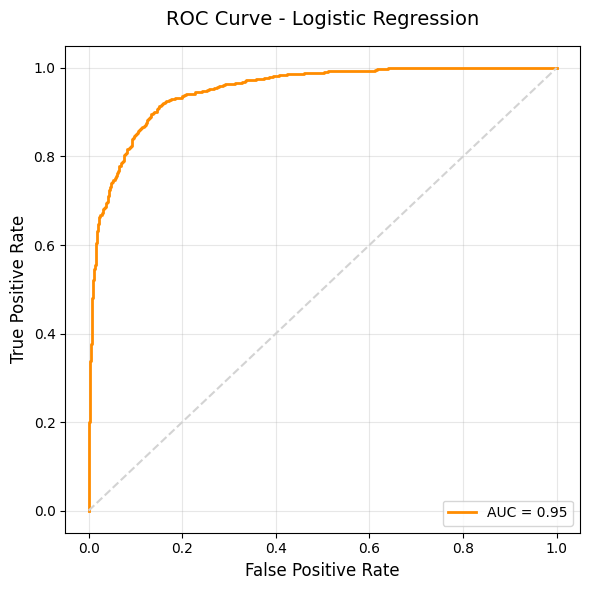

```python
from sklearn.metrics import accuracy_score, classification_report, roc_curve, auc
import matplotlib.pyplot as plt

# Report
print("\nClassification Report:\n===============")
y_pred = log_reg.predict(X_test)
print(classification_report(y_test, y_pred))

# ROC curve
probabilities = log_reg.predict_proba(X_test)
fpr, tpr, thresholds = roc_curve(y_test, probabilities[:, 1])
roc_auc = auc(fpr, tpr)

plt.figure(figsize=(6, 6))
plt.plot(fpr, tpr, color='darkorange', lw=2, label=f'AUC = {roc_auc:.2f}')
plt.plot([0, 1], [0, 1], color='lightgray', lw=1.5, linestyle='--')
plt.xlabel('False Positive Rate', fontsize=12)
plt.ylabel('True Positive Rate', fontsize=12)
plt.title('ROC Curve - Logistic Regression', fontsize=14, pad=15)
plt.legend(loc="lower right", fontsize=10)
plt.grid(alpha=0.3)
plt.tight_layout()
plt.show()
```

Thus, it is clear that the predictions of the LR model are quite accurate. Where the type of error remains the same for both classes.

Now, given the internal functioning of the model (based on independent tokens), it is possible to check which words have the greatest influence on the classification.

```python
# Explainability
class_labels = log_reg.classes_
feature_names = vectorizer.get_feature_names_out()
negative = sorted(zip(log_reg.coef_[0], feature_names))[:15]
positive = sorted(zip(log_reg.coef_[0], feature_names))[-15:]
print("MOST INFLUENTIAL\n")
print("--------Positive--------")
for coef, feat in positive:
    print(class_labels[0], coef.round(3), feat)
print("\n--------Negative--------")
for coef, feat in reversed(negative):
    print(class_labels[1], coef.round(3), feat)
```

```
MOST INFLUENTIAL

--------Positive--------
0 2.635 hilarious
0 2.796 superb
0 2.797 highly
0 2.8 today
0 2.929 well
0 2.994 perfect
0 3.119 love
0 3.148 loved
0 3.171 favorite
0 3.171 enjoyed
0 3.175 wonderful
0 3.245 amazing
```

[output cut: 20 more lines]

Surprisingly, these results show that the words "*script*" and "*minutes*" are considered so negative, even on par with "*horrible*" and "*crap*". Therefore, these weights prove that these concepts are often used to criticize films negatively.

## 4.2 Transofmers: BERT based model

In this case, no additional preprocessing is applied beyond the cleaning steps described in Section 1.2. Stopwords are kept, and the most frequent words (e.g. top 0.05) are not removed. This choice is motivated by the fact that Transformer-based models operate directly on tokenized text and leverage self-attention to capture contextual relationships. As a result, traditional preprocessing steps like stopword removal or frequency-based filtering are less critical, since the model can learn to downweight irrelevant or ubiquitous tokens during training.

```python
%%capture
!pip install transformers datasets torch scikit-learn accelerate
```

```python
import pandas as pd
import numpy as np
import matplotlib.pyplot as plt
from datasets import Dataset
from transformers import AutoTokenizer

# Prepare dataset with stratified partitioning
labels = df['sentiment'].tolist()
df['label'] = [0 if label == 'negative' else 1 for label in labels]

train_df, test_df = train_test_split(df, test_size=0.2, random_state=1, stratify=df['label'])
train_dataset = Dataset.from_pandas(train_df)
test_dataset = Dataset.from_pandas(test_df)

# Tokenize
model_name = "distilbert-base-uncased"
tokenizer = AutoTokenizer.from_pretrained(model_name)

def tokenize_function(examples):
    return tokenizer(examples["text"], padding="max_length", truncation=True)

train_tokenized = train_dataset.map(tokenize_function, batched=True)
test_tokenized = test_dataset.map(tokenize_function, batched=True)
```

```python
%%capture
from transformers import AutoModelForSequenceClassification, TrainingArguments, Trainer

# Load Model & Define the training process
model = AutoModelForSequenceClassification.from_pretrained(model_name, num_labels=2)

training_args = TrainingArguments(
    output_dir="./results",
    num_train_epochs=3,
    per_device_train_batch_size=16,
    per_device_eval_batch_size=64,
    warmup_steps=500,
    weight_decay=0.01,
    logging_dir="./logs",
    logging_strategy="epoch",
    eval_strategy="epoch",
    save_strategy="epoch",
    load_best_model_at_end=True,
    report_to="none"
)

def compute_metrics(eval_pred):
    logits, labels = eval_pred
    predictions = np.argmax(logits, axis=-1)
    report = classification_report(labels, predictions, output_dict=True)
    return {"accuracy": report["accuracy"], "f1": report["macro avg"]["f1-score"]}

trainer = Trainer(
    model=model,
    args=training_args,
    train_dataset=train_tokenized,
    eval_dataset=test_tokenized,
    compute_metrics=compute_metrics,
)
```

```
Some weights of DistilBertForSequenceClassification were not initialized from the model checkpoint at distilbert-base-uncased and are newly initialized: ['classifier.bias', 'classifier.weight', 'pre_classifier.bias', 'pre_classifier.weight']
You should probably TRAIN this model on a down-stream task to be able to use it for predictions and inference.
```

```python
trainer.train() # From now on, GPU is required
```

[1860/1860 27:56, Epoch 3/3]

| Epoch | Training Loss | Validation Loss | Accuracy | F1 |
| --- | --- | --- | --- | --- |
| 1 | 0.369000 | 0.225610 | 0.905645 | 0.905409 |
| 2 | 0.187200 | 0.207101 | 0.925806 | 0.925802 |
| 3 | 0.075100 | 0.310638 | 0.924194 | 0.924193 |

```
TrainOutput(global_step=1860, training_loss=0.21042110073950984, metrics={'train_runtime': 1679.1105, 'train_samples_per_second': 17.717, 'train_steps_per_second': 1.108, 'total_flos': 3940640175218688.0, 'train_loss': 0.21042110073950984, 'epoch': 3.0})
```

```python
from google.colab import drive
drive.mount('/content/drive')

# Save best model (epoch 2) & tokenizer
model.save_pretrained('/content/drive/MyDrive/distilbert_sentiment')
tokenizer.save_pretrained('/content/drive/MyDrive/distilbert_sentiment')
```

```
('/content/drive/MyDrive/distilbert_sentiment/tokenizer_config.json',
 '/content/drive/MyDrive/distilbert_sentiment/special_tokens_map.json',
 '/content/drive/MyDrive/distilbert_sentiment/vocab.txt',
 '/content/drive/MyDrive/distilbert_sentiment/added_tokens.json',
 '/content/drive/MyDrive/distilbert_sentiment/tokenizer.json')
```

```python
from google.colab import drive
# Execute in a new session
drive.mount('/content/drive')
```

```python
from transformers import TrainingArguments, Trainer, AutoModelForSequenceClassification

# Load trained model
model_path = "/content/drive/MyDrive/distilbert_sentiment"
model = AutoModelForSequenceClassification.from_pretrained(model_path)
tokenizer = AutoTokenizer.from_pretrained(model_path)

training_args = TrainingArguments(
    output_dir="./results",
    per_device_eval_batch_size=64,
    report_to="none"
)

trainer = Trainer(
    model=model,
    args=training_args,
    eval_dataset=test_tokenized
)
```

```
Classification Report:
===============
              precision    recall  f1-score   support

    negative       0.93      0.92      0.93      1237
    positive       0.92      0.93      0.93      1243

    accuracy                           0.93      2480
   macro avg       0.93      0.93      0.93      2480
weighted avg       0.93      0.93      0.93      2480
```

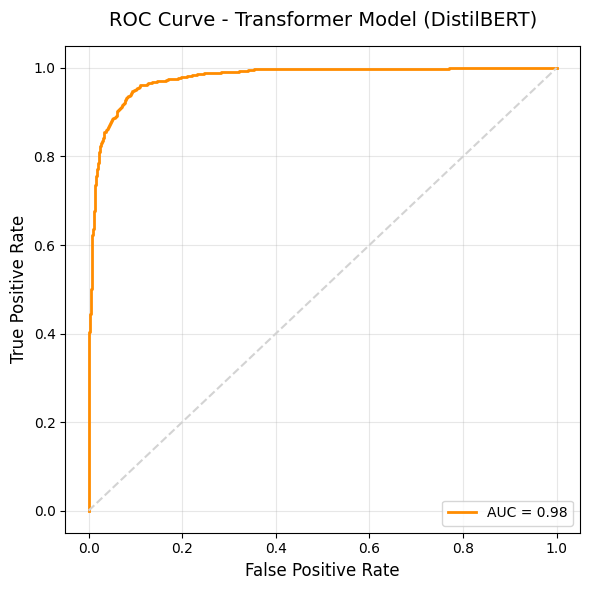

```python
from scipy.special import softmax
from sklearn.metrics import classification_report, roc_curve, auc

# Predict
predictions_output = trainer.predict(test_tokenized)
predicted_labels = np.argmax(predictions_output.predictions, axis=1)
true_labels = predictions_output.label_ids
probabilities = softmax(predictions_output.predictions, axis=1)
positive_scores = probabilities[:, 1]

# Report
print("Classification Report:\n===============")
class_names = ['negative', 'positive']
print(classification_report(true_labels, predicted_labels, target_names=class_names))

# AUC
fpr, tpr, thresholds = roc_curve(true_labels, positive_scores)
roc_auc = auc(fpr, tpr)

plt.figure(figsize=(6, 6))
plt.plot(fpr, tpr, color='darkorange', lw=2, label=f'AUC = {roc_auc:.2f}')
plt.plot([0, 1], [0, 1], color='lightgray', lw=1.5, linestyle='--')
plt.xlabel('False Positive Rate', fontsize=12)
plt.ylabel('True Positive Rate', fontsize=12)
plt.title('ROC Curve - Transformer Model (DistilBERT)', fontsize=14, pad=15)
plt.legend(loc="lower right", fontsize=10)
plt.grid(alpha=0.3)
plt.tight_layout()
plt.show()
```

### **Model Comparison: LR vs. DistilBERT**

```python
test_review = "The movie had a great story and fantastic setting, but the acting ruined it."

# LR
start_time = time.time()
test_vectorized = vectorizer.transform([test_review])
log_reg_pred = log_reg.predict(test_vectorized)
log_reg_prob = log_reg.predict_proba(test_vectorized)
end_time = time.time()
log_reg_inference_time = end_time - start_time

print("Logistic Regression Prediction:", "positive" if log_reg_pred[0] == 1 else "negative")
print("Probabilities:", log_reg_prob)
print(f"Inference time: {log_reg_inference_time:.6f} seconds\n")

# DistilBERT
from datasets import Dataset
test_dataset_single = Dataset.from_dict({"text": [test_review]})
test_tokenized_single = test_dataset_single.map(tokenize_function)

start_time = time.time()
predictions_output = trainer.predict(test_tokenized_single)
probs = softmax(predictions_output.predictions, axis=1)
bert_pred = np.argmax(probs, axis=1)[0]
end_time = time.time()
bert_inference_time = end_time - start_time

print("DistilBERT Prediction:", "positive" if bert_pred == 1 else "negative")
print("Probabilities:", probs)
print(f"Inference time: {bert_inference_time:.6f} seconds")
```

```
Logistic Regression Prediction: positive
Probabilities: [[0.1140709 0.8859291]]
Inference time: 0.010610 seconds
```

```
DistilBERT Prediction: negative
Probabilities: [[0.97370726 0.02629277]]
Inference time: 0.050776 seconds
```

The results show a consistent advantage for the transformer-based model (DistilBERT) over the LR baseline across all evaluation metrics:

- **LR model**: Accuracy = 0.88, F1 = 0.88, AUC = 0.95
- **DistilBERT**: Accuracy = 0.93, F1 = 0.93, AUC = 0.98

These values indicate a small but clear improvement for DistilBERT, while maintaining balanced performance in both classes.

#### **Conclusion**

DistilBERT delivers superior predictive performance and more robust generalization, thanks to its ability to understand context and handle novel vocabulary. This advantage comes at the cost of significantly higher training time and greater computational requirements.

The LR model remains a strong baseline, proving to be a practical alternative in scenarios where limited resources, rapid training cycles, or minimal-latency CPU inference are prioritized. The final choice between the models depends on the specific balance required between state-of-the-art accuracy and the operational constraints of the project.